# ML Project

Aaron Adair

8/5/2018

# Modeling with Machine Learning Techniques

## Model built

The expacted outcome variable is classe, a 5 level of factor variable. In this dataset, participants were asked to perform one set of 10 repetitions of the Unilateral Dumbbell Biceps Curl in 5 different fashion: Class A - excatly according to the specification, Class B - throwing the elbows to the front, Class c- lifting the dumbbell only halfway, Class D - lowering the dumbbell only halfway, Class E - throwing the hips to the front.

There are a lot of libraries to be useful for the ML work here.

```r
library(ggplot2)
library(lattice)
library(randomForest)
library(e1071)
library(caret)
library(rpart)
library(rpart.plot)
set.seed(3333)
```

We get the data from our online source and read it into a training and testing set.

```r
trainUrl <- "https://d396qusza40orc.cloudfront.net/predmachlearn/pml-training.csv"
testUrl <- "https://d396qusza40orc.cloudfront.net/predmachlearn/pml-testing.csv"


trainingData <- read.csv(url(trainUrl), na.strings = c("NA", "#DIV/0!", ""))
testingData <- read.csv(url(testUrl), na.strings = c("NA", "#DIV/0!", ""))

trainingData <- trainingData[, colSums(is.na(trainingData)) == 0]
testingData <- testingData[, colSums(is.na(testingData)) == 0]

trainingData <- trainingData[, -c(1:7)]
testingData <- testingData[, -c(1:7)]


traningPartitionData <- createDataPartition(trainingData$classe,  p = 0.7, list = F)
trainingDataSet <- trainingData[traningPartitionData, ]
testingDataSet <- trainingData[-traningPartitionData, ]
dim(trainingData)
```

```
## [1] 19622    53
```

```r
dim(testingDataSet)
```

```
## [1] 5885   53
```

# Decision Tree

First, we use a decision tree to sort out and train a model.

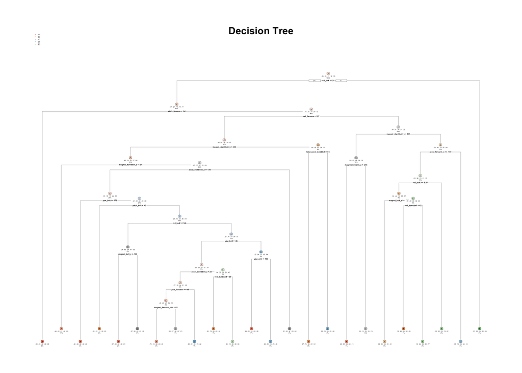

```r
decisionTreeModel <- rpart(classe ~ ., data = trainingDataSet, method = "class")
decisionTreePrediction <- predict(decisionTreeModel, testingDataSet, type = "class")

rpart.plot(decisionTreeModel, main = "Decision Tree", under = T, faclen = 0)
```

```r
confusionMatrix(decisionTreePrediction, testingDataSet$classe)
```

```
## Confusion Matrix and Statistics
##
##           Reference
## Prediction    A    B    C    D    E
##          A 1539  244   27   89   35
##          B   36  636   97   46   92
##          C   54  135  851  147  123
##          D   15  104   51  608   79
##          E   30   20    0   74  753
##
## Overall Statistics
##
##                Accuracy : 0.7455
##                  95% CI : (0.7341, 0.7565)
##     No Information Rate : 0.2845
##     P-Value [Acc > NIR] : < 2.2e-16
##
##                   Kappa : 0.6764
##  Mcnemar's Test P-Value : < 2.2e-16
##
## Statistics by Class:
##
##                      Class: A Class: B Class: C Class: D Class: E
## Sensitivity            0.9194   0.5584   0.8294   0.6307   0.6959
## Specificity            0.9062   0.9429   0.9055   0.9494   0.9742
## Pos Pred Value         0.7958   0.7012   0.6496   0.7095   0.8586
## Neg Pred Value         0.9658   0.8990   0.9617   0.9292   0.9343
## Prevalence             0.2845   0.1935   0.1743   0.1638   0.1839
## Detection Rate         0.2615   0.1081   0.1446   0.1033   0.1280
## Detection Prevalence   0.3286   0.1541   0.2226   0.1456   0.1490
## Balanced Accuracy      0.9128   0.7506   0.8675   0.7901   0.8351
```

Not too bad, with a fairly high accuracy. However, the branching of the decision tree doesn’t look too great; there isn’t a nice division between groups early on, so the branching is probably not going to be great in the long run. Let’s try another route.

# Random Forest

Here, we employ the random forest technique.

```r
randomForestModel <- randomForest(classe ~. , data = trainingDataSet, method = "class")
randomForestPrediction <- predict(randomForestModel, testingDataSet, type = "class")

confusionMatrix(randomForestPrediction, testingDataSet$classe)
```

```
## Confusion Matrix and Statistics
##
##           Reference
## Prediction    A    B    C    D    E
##          A 1674    4    0    0    0
##          B    0 1134    9    0    0
##          C    0    1 1017    7    0
##          D    0    0    0  957    1
##          E    0    0    0    0 1081
##
## Overall Statistics
##
##                Accuracy : 0.9963
##                  95% CI : (0.9943, 0.9977)
##     No Information Rate : 0.2845
##     P-Value [Acc > NIR] : < 2.2e-16
##
##                   Kappa : 0.9953
##  Mcnemar's Test P-Value : NA
##
## Statistics by Class:
##
##                      Class: A Class: B Class: C Class: D Class: E
## Sensitivity            1.0000   0.9956   0.9912   0.9927   0.9991
## Specificity            0.9991   0.9981   0.9984   0.9998   1.0000
## Pos Pred Value         0.9976   0.9921   0.9922   0.9990   1.0000
## Neg Pred Value         1.0000   0.9989   0.9981   0.9986   0.9998
## Prevalence             0.2845   0.1935   0.1743   0.1638   0.1839
## Detection Rate         0.2845   0.1927   0.1728   0.1626   0.1837
## Detection Prevalence   0.2851   0.1942   0.1742   0.1628   0.1837
## Balanced Accuracy      0.9995   0.9969   0.9948   0.9963   0.9995
```

The accuracy of the random forest was better than the decision tree in this case (99.6% compared to 74.6%)